# Case Study-1

### Case Study - 1

```python
#importing the required libraries

import pandas as pd
import numpy as np
import seaborn as sns
import matplotlib.pyplot as plt
```

```python
#Reading the csv file

loans_data=pd.read_csv("loans_full_schema.csv")
type(loans_data)
```

```
pandas.core.frame.DataFrame
```

## 1. Describe the dataset and any issues with it.

#### As shown below, the dataset contains 10000 rows and 55 coulmns.

```python
#Printing the number of rows of dataset
print(len(loans_data))

#Printing the dimensionality of the dataset
print(loans_data.shape)
```

```
10000
(10000, 55)
```

#### Displaying all the columns and their data types as shown below.

```python
loans_data.info()
```

```
<class 'pandas.core.frame.DataFrame'>
RangeIndex: 10000 entries, 0 to 9999
Data columns (total 55 columns):
emp_title                           9167 non-null object
emp_length                          9183 non-null float64
state                               10000 non-null object
homeownership                       10000 non-null object
annual_income                       10000 non-null float64
verified_income                     10000 non-null object
debt_to_income                      9976 non-null float64
annual_income_joint                 1495 non-null float64
verification_income_joint           1455 non-null object
debt_to_income_joint                1495 non-null float64
delinq_2y                           10000 non-null int64
months_since_last_delinq            4342 non-null float64
earliest_credit_line                10000 non-null int64
inquiries_last_12m                  10000 non-null int64
total_credit_lines                  10000 non-null int64
open_credit_lines                   10000 non-null int64
total_credit_limit                  10000 non-null int64
total_credit_utilized               10000 non-null int64
num_collections_last_12m            10000 non-null int64
num_historical_failed_to_pay        10000 non-null int64
months_since_90d_late               2285 non-null float64
current_accounts_delinq             10000 non-null int64
total_collection_amount_ever        10000 non-null int64
current_installment_accounts        10000 non-null int64
accounts_opened_24m                 10000 non-null int64
months_since_last_credit_inquiry    8729 non-null float64
num_satisfactory_accounts           10000 non-null int64
num_accounts_120d_past_due          9682 non-null float64
num_accounts_30d_past_due           10000 non-null int64
num_active_debit_accounts           10000 non-null int64
total_debit_limit                   10000 non-null int64
num_total_cc_accounts               10000 non-null int64
num_open_cc_accounts                10000 non-null int64
num_cc_carrying_balance             10000 non-null int64
num_mort_accounts                   10000 non-null int64
account_never_delinq_percent        10000 non-null float64
tax_liens                           10000 non-null int64
public_record_bankrupt              10000 non-null int64
loan_purpose                        10000 non-null object
application_type                    10000 non-null object
loan_amount                         10000 non-null int64
term                                10000 non-null int64
interest_rate                       10000 non-null float64
installment                         10000 non-null float64
grade                               10000 non-null object
sub_grade                           10000 non-null object
issue_month                         10000 non-null object
loan_status                         10000 non-null object
initial_listing_status              10000 non-null object
disbursement_method                 10000 non-null object
balance                             10000 non-null float64
paid_total                          10000 non-null float64
paid_principal                      10000 non-null float64
paid_interest                       10000 non-null float64
paid_late_fees                      10000 non-null float64
dtypes: float64(17), int64(25), object(13)
memory usage: 4.2+ MB
```

```python
# Displaying the first 5 rows of dataset

loans_data.head()
```

|  | emp_title | emp_length | state | homeownership | annual_income | verified_income | debt_to_income | annual_income_joint | verification_income_joint | debt_to_income_joint | ... | sub_grade | issue_month | loan_status | initial_listing_status | disbursement_method | balance | paid_total | paid_principal | paid_interest | paid_late_fees |
| --- | --- | --- | --- | --- | --- | --- | --- | --- | --- | --- | --- | --- | --- | --- | --- | --- | --- | --- | --- | --- | --- |
| 0 | global config engineer | 3.0 | NJ | MORTGAGE | 90000.0 | Verified | 18.01 | NaN | NaN | NaN | ... | C3 | Mar-2018 | Current | whole | Cash | 27015.86 | 1999.33 | 984.14 | 1015.19 | 0.0 |
| 1 | warehouse office clerk | 10.0 | HI | RENT | 40000.0 | Not Verified | 5.04 | NaN | NaN | NaN | ... | C1 | Feb-2018 | Current | whole | Cash | 4651.37 | 499.12 | 348.63 | 150.49 | 0.0 |
| 2 | assembly | 3.0 | WI | RENT | 40000.0 | Source Verified | 21.15 | NaN | NaN | NaN | ... | D1 | Feb-2018 | Current | fractional | Cash | 1824.63 | 281.80 | 175.37 | 106.43 | 0.0 |
| 3 | customer service | 1.0 | PA | RENT | 30000.0 | Not Verified | 10.16 | NaN | NaN | NaN | ... | A3 | Jan-2018 | Current | whole | Cash | 18853.26 | 3312.89 | 2746.74 | 566.15 | 0.0 |
| 4 | security supervisor | 10.0 | CA | RENT | 35000.0 | Verified | 57.96 | 57000.0 | Verified | 37.66 | ... | C3 | Mar-2018 | Current | whole | Cash | 21430.15 | 2324.65 | 1569.85 | 754.80 | 0.0 |

5 rows × 55 columns

```python
# Displaying the last five rows of dataset

loans_data.tail()
```

|  | emp_title | emp_length | state | homeownership | annual_income | verified_income | debt_to_income | annual_income_joint | verification_income_joint | debt_to_income_joint | ... | sub_grade | issue_month | loan_status | initial_listing_status | disbursement_method | balance | paid_total | paid_principal | paid_interest | paid_late_fees |
| --- | --- | --- | --- | --- | --- | --- | --- | --- | --- | --- | --- | --- | --- | --- | --- | --- | --- | --- | --- | --- | --- |
| 9995 | owner | 10.0 | TX | RENT | 108000.0 | Source Verified | 22.28 | NaN | NaN | NaN | ... | A4 | Jan-2018 | Current | whole | Cash | 21586.34 | 2969.80 | 2413.66 | 556.14 | 0.0 |
| 9996 | director | 8.0 | PA | MORTGAGE | 121000.0 | Verified | 32.38 | NaN | NaN | NaN | ... | D3 | Feb-2018 | Current | whole | Cash | 9147.44 | 1456.31 | 852.56 | 603.75 | 0.0 |
| 9997 | toolmaker | 10.0 | CT | MORTGAGE | 67000.0 | Verified | 45.26 | 107000.0 | Source Verified | 29.57 | ... | E2 | Feb-2018 | Current | fractional | Cash | 27617.65 | 4620.80 | 2382.35 | 2238.45 | 0.0 |
| 9998 | manager | 1.0 | WI | MORTGAGE | 80000.0 | Source Verified | 11.99 | NaN | NaN | NaN | ... | A1 | Feb-2018 | Current | whole | Cash | 21518.12 | 2873.31 | 2481.88 | 391.43 | 0.0 |
| 9999 | operations analyst | 3.0 | CT | RENT | 66000.0 | Not Verified | 20.82 | NaN | NaN | NaN | ... | B4 | Feb-2018 | Current | whole | Cash | 11574.83 | 1658.56 | 1225.17 | 433.39 | 0.0 |

5 rows × 55 columns

#### Displaying the descriptive statistics for all columns as displayed below.

```python
loans_data.describe()
```

|  | emp_length | annual_income | debt_to_income | annual_income_joint | debt_to_income_joint | delinq_2y | months_since_last_delinq | earliest_credit_line | inquiries_last_12m | total_credit_lines | ... | public_record_bankrupt | loan_amount | term | interest_rate | installment | balance | paid_total | paid_principal | paid_interest | paid_late_fees |
| --- | --- | --- | --- | --- | --- | --- | --- | --- | --- | --- | --- | --- | --- | --- | --- | --- | --- | --- | --- | --- | --- |
| count | 9183.000000 | 1.000000e+04 | 9976.000000 | 1.495000e+03 | 1495.000000 | 10000.00000 | 4342.000000 | 10000.00000 | 10000.00000 | 10000.000000 | ... | 10000.000000 | 10000.000000 | 10000.000000 | 10000.000000 | 10000.000000 | 10000.000000 | 10000.000000 | 10000.000000 | 10000.000000 | 10000.000000 |
| mean | 5.930306 | 7.922215e+04 | 19.308192 | 1.279146e+05 | 19.979304 | 0.21600 | 36.760709 | 2001.29000 | 1.95820 | 22.679600 | ... | 0.123800 | 16361.922500 | 43.272000 | 12.427524 | 476.205323 | 14458.916610 | 2494.234773 | 1894.448466 | 599.666781 | 0.119516 |
| std | 3.703734 | 6.473429e+04 | 15.004851 | 7.016838e+04 | 8.054781 | 0.68366 | 21.634939 | 7.79551 | 2.38013 | 11.885439 | ... | 0.337172 | 10301.956759 | 11.029877 | 5.001105 | 294.851627 | 9964.561865 | 3958.230365 | 3884.407175 | 517.328062 | 1.813468 |
| min | 0.000000 | 0.000000e+00 | 0.000000 | 1.920000e+04 | 0.320000 | 0.00000 | 1.000000 | 1963.00000 | 0.00000 | 2.000000 | ... | 0.000000 | 1000.000000 | 36.000000 | 5.310000 | 30.750000 | 0.000000 | 0.000000 | 0.000000 | 0.000000 | 0.000000 |
| 25% | 2.000000 | 4.500000e+04 | 11.057500 | 8.683350e+04 | 14.160000 | 0.00000 | 19.000000 | 1997.00000 | 0.00000 | 14.000000 | ... | 0.000000 | 8000.000000 | 36.000000 | 9.430000 | 256.040000 | 6679.065000 | 928.700000 | 587.100000 | 221.757500 | 0.000000 |
| 50% | 6.000000 | 6.500000e+04 | 17.570000 | 1.130000e+05 | 19.720000 | 0.00000 | 34.000000 | 2003.00000 | 1.00000 | 21.000000 | ... | 0.000000 | 14500.000000 | 36.000000 | 11.980000 | 398.420000 | 12379.495000 | 1563.300000 | 984.990000 | 446.140000 | 0.000000 |
| 75% | 10.000000 | 9.500000e+04 | 25.002500 | 1.515455e+05 | 25.500000 | 0.00000 | 53.000000 | 2006.00000 | 3.00000 | 29.000000 | ... | 0.000000 | 24000.000000 | 60.000000 | 15.050000 | 644.690000 | 20690.182500 | 2616.005000 | 1694.555000 | 825.420000 | 0.000000 |
| max | 10.000000 | 2.300000e+06 | 469.090000 | 1.100000e+06 | 39.980000 | 13.00000 | 118.000000 | 2015.00000 | 29.00000 | 87.000000 | ... | 3.000000 | 40000.000000 | 60.000000 | 30.940000 | 1566.590000 | 40000.000000 | 41630.443684 | 40000.000000 | 4216.440000 | 52.980000 |

8 rows × 42 columns

### Issues with respect to the dataset:

#### 1. Detecting the null values:

```python
# To detect the missing values which returns True for NA values else False.

loans_data.isna()
```

|  | emp_title | emp_length | state | homeownership | annual_income | verified_income | debt_to_income | annual_income_joint | verification_income_joint | debt_to_income_joint | ... | sub_grade | issue_month | loan_status | initial_listing_status | disbursement_method | balance | paid_total | paid_principal | paid_interest | paid_late_fees |
| --- | --- | --- | --- | --- | --- | --- | --- | --- | --- | --- | --- | --- | --- | --- | --- | --- | --- | --- | --- | --- | --- |
| 0 | False | False | False | False | False | False | False | True | True | True | ... | False | False | False | False | False | False | False | False | False | False |
| 1 | False | False | False | False | False | False | False | True | True | True | ... | False | False | False | False | False | False | False | False | False | False |
| 2 | False | False | False | False | False | False | False | True | True | True | ... | False | False | False | False | False | False | False | False | False | False |
| 3 | False | False | False | False | False | False | False | True | True | True | ... | False | False | False | False | False | False | False | False | False | False |
| 4 | False | False | False | False | False | False | False | False | False | False | ... | False | False | False | False | False | False | False | False | False | False |
| ... | ... | ... | ... | ... | ... | ... | ... | ... | ... | ... | ... | ... | ... | ... | ... | ... | ... | ... | ... | ... | ... |
| 9995 | False | False | False | False | False | False | False | True | True | True | ... | False | False | False | False | False | False | False | False | False | False |
| 9996 | False | False | False | False | False | False | False | True | True | True | ... | False | False | False | False | False | False | False | False | False | False |
| 9997 | False | False | False | False | False | False | False | False | False | False | ... | False | False | False | False | False | False | False | False | False | False |
| 9998 | False | False | False | False | False | False | False | True | True | True | ... | False | False | False | False | False | False | False | False | False | False |
| 9999 | False | False | False | False | False | False | False | True | True | True | ... | False | False | False | False | False | False | False | False | False | False |

10000 rows × 55 columns

```python
# This prints the total number of missing values for each column.

loans_data.isna().sum()
```

```
emp_title                            833
emp_length                           817
state                                  0
homeownership                          0
annual_income                          0
verified_income                        0
debt_to_income                        24
annual_income_joint                 8505
verification_income_joint           8545
debt_to_income_joint                8505
delinq_2y                              0
months_since_last_delinq            5658
earliest_credit_line                   0
inquiries_last_12m                     0
total_credit_lines                     0
open_credit_lines                      0
total_credit_limit                     0
total_credit_utilized                  0
num_collections_last_12m               0
num_historical_failed_to_pay           0
months_since_90d_late               7715
current_accounts_delinq                0
total_collection_amount_ever           0
current_installment_accounts           0
accounts_opened_24m                    0
months_since_last_credit_inquiry    1271
num_satisfactory_accounts              0
num_accounts_120d_past_due           318
num_accounts_30d_past_due              0
num_active_debit_accounts              0
total_debit_limit                      0
num_total_cc_accounts                  0
num_open_cc_accounts                   0
num_cc_carrying_balance                0
num_mort_accounts                      0
account_never_delinq_percent           0
tax_liens                              0
public_record_bankrupt                 0
loan_purpose                           0
application_type                       0
loan_amount                            0
term                                   0
interest_rate                          0
installment                            0
grade                                  0
sub_grade                              0
issue_month                            0
loan_status                            0
initial_listing_status                 0
disbursement_method                    0
balance                                0
paid_total                             0
paid_principal                         0
paid_interest                          0
paid_late_fees                         0
dtype: int64
```

```python
# Total number of missing values in the entire dataset.

loans_data.isna().sum().sum()
```

```
42191
```

### Solutions to fix the issues wrt null values:

```python
# Drops the rows containg the null values

clean_loans_data=loans_data.dropna()
clean_loans_data.shape
```

```
(201, 55)
```

###### As shown above, the number of rows has been reduced to 201. Hence, by dropping the rows containing null values can result in loss of necessary information.

```python
# The other way to fix this issue is by filling the null values with a fixed value like zero

clean_data=loans_data.fillna(value=0, inplace=True)
```

#### 2. Detecting duplicates:

```python
# Apart from missing data, there can also be duplicate rows in a dataframe.

duplicate_loans_data= loans_data[loans_data.duplicated()]
duplicate_loans_data.shape
```

```
(0, 55)
```

### Solution to fix the issues wrt duplicates:

```python
# But if there are any duplicates, it can be removed as shown below.

loans_data.drop_duplicates()
```

|  | emp_title | emp_length | state | homeownership | annual_income | verified_income | debt_to_income | annual_income_joint | verification_income_joint | debt_to_income_joint | ... | sub_grade | issue_month | loan_status | initial_listing_status | disbursement_method | balance | paid_total | paid_principal | paid_interest | paid_late_fees |
| --- | --- | --- | --- | --- | --- | --- | --- | --- | --- | --- | --- | --- | --- | --- | --- | --- | --- | --- | --- | --- | --- |
| 0 | global config engineer | 3.0 | NJ | MORTGAGE | 90000.0 | Verified | 18.01 | 0.0 | 0 | 0.00 | ... | C3 | Mar-2018 | Current | whole | Cash | 27015.86 | 1999.33 | 984.14 | 1015.19 | 0.0 |
| 1 | warehouse office clerk | 10.0 | HI | RENT | 40000.0 | Not Verified | 5.04 | 0.0 | 0 | 0.00 | ... | C1 | Feb-2018 | Current | whole | Cash | 4651.37 | 499.12 | 348.63 | 150.49 | 0.0 |
| 2 | assembly | 3.0 | WI | RENT | 40000.0 | Source Verified | 21.15 | 0.0 | 0 | 0.00 | ... | D1 | Feb-2018 | Current | fractional | Cash | 1824.63 | 281.80 | 175.37 | 106.43 | 0.0 |
| 3 | customer service | 1.0 | PA | RENT | 30000.0 | Not Verified | 10.16 | 0.0 | 0 | 0.00 | ... | A3 | Jan-2018 | Current | whole | Cash | 18853.26 | 3312.89 | 2746.74 | 566.15 | 0.0 |
| 4 | security supervisor | 10.0 | CA | RENT | 35000.0 | Verified | 57.96 | 57000.0 | Verified | 37.66 | ... | C3 | Mar-2018 | Current | whole | Cash | 21430.15 | 2324.65 | 1569.85 | 754.80 | 0.0 |
| ... | ... | ... | ... | ... | ... | ... | ... | ... | ... | ... | ... | ... | ... | ... | ... | ... | ... | ... | ... | ... | ... |
| 9995 | owner | 10.0 | TX | RENT | 108000.0 | Source Verified | 22.28 | 0.0 | 0 | 0.00 | ... | A4 | Jan-2018 | Current | whole | Cash | 21586.34 | 2969.80 | 2413.66 | 556.14 | 0.0 |
| 9996 | director | 8.0 | PA | MORTGAGE | 121000.0 | Verified | 32.38 | 0.0 | 0 | 0.00 | ... | D3 | Feb-2018 | Current | whole | Cash | 9147.44 | 1456.31 | 852.56 | 603.75 | 0.0 |
| 9997 | toolmaker | 10.0 | CT | MORTGAGE | 67000.0 | Verified | 45.26 | 107000.0 | Source Verified | 29.57 | ... | E2 | Feb-2018 | Current | fractional | Cash | 27617.65 | 4620.80 | 2382.35 | 2238.45 | 0.0 |
| 9998 | manager | 1.0 | WI | MORTGAGE | 80000.0 | Source Verified | 11.99 | 0.0 | 0 | 0.00 | ... | A1 | Feb-2018 | Current | whole | Cash | 21518.12 | 2873.31 | 2481.88 | 391.43 | 0.0 |
| 9999 | operations analyst | 3.0 | CT | RENT | 66000.0 | Not Verified | 20.82 | 0.0 | 0 | 0.00 | ... | B4 | Feb-2018 | Current | whole | Cash | 11574.83 | 1658.56 | 1225.17 | 433.39 | 0.0 |

10000 rows × 55 columns

#### 3. Another aspect would be detecting outliers in dataset which is an important segment in Exploratory Data Analysis. Outliers can play havoc when we want to apply Machine Learning algorithms for predictions.

## 2. Generate a minimum of 5 unique visualizations using the data and write a brief description of your observations.

### 1. Trends of Annual Income and Loan Amounts

#### The below distribution plot the variation in the distribution of Annual Income and Loan Amounts. We can see from the below graphs that the Annual Income mostly lie between 0 and 500000 and the maximum number of Loan Amount taken is approx 10000.

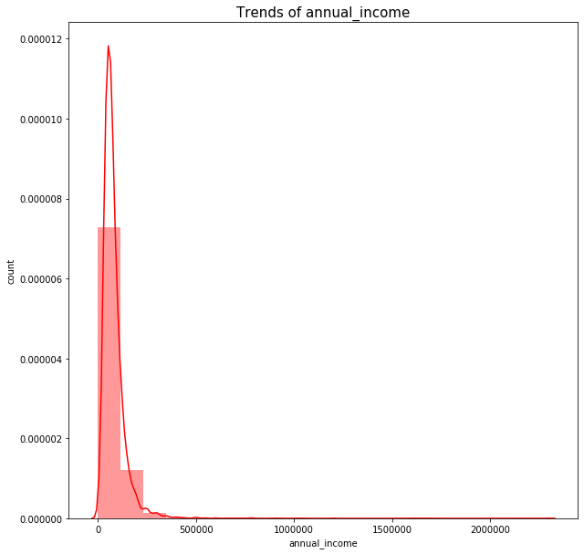

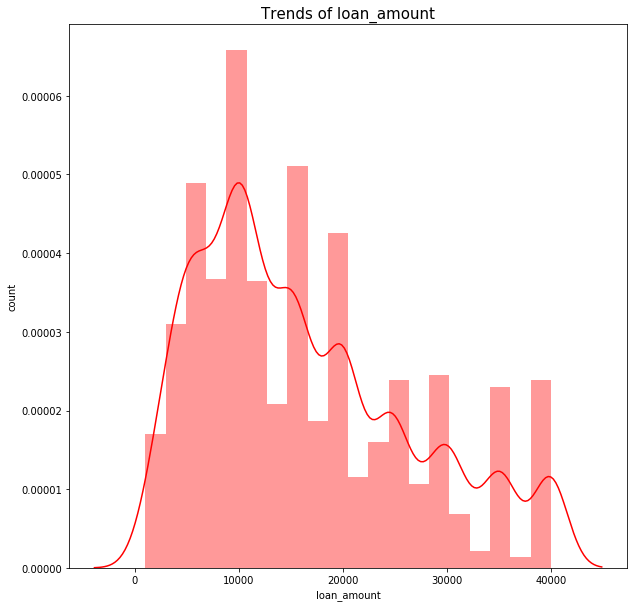

```python
Amounts = ['annual_income','loan_amount']
for i in Amounts:
    sns.distplot(loans_data[i],color="red",bins=20)
    plt.title("Trends of "+ i, fontsize=15)
    plt.xlabel(i)
    plt.ylabel('count')
    plt.show()
```